# LiDAR

Actualmente los vehículos autónomos se dice que son de Nivel 2, es decir, requieren atención por parte del conductor para evitar accidentes. Lo que se espera es que en un futuro se llegue a niveles 3 o 4, donde el vehículo ya sería completamente autónomo, requiriendo muy poca atención por parte del conductor.

## LIDAR

LiDAR es un sistema de detección basado en pulsos de láser. En vehícuos autónomos se tienen dos diferentes escenarios, la conducción por carretera y conducción en ciudades, donde cada uno de los diferentes escenarios presentan retos distintos, siendo la conducción urbana la más complicada. Para el diseño de un sistema de conducción autónoma se deben tomar en cuenta diferentes aspectos, por ejemplo, la velocidad, ya que si queremos que el vehículo vaya más rápido, entonces necesitaremos aumentar el frame rate para obtener imágenes con más frecuencia y así tomar las mejores decisiones.

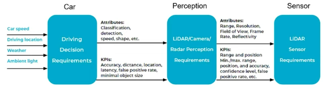

También influyen otros aspectos como el diseño del vehículo.

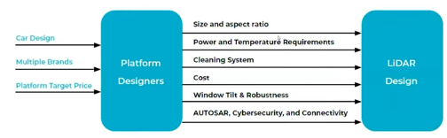

Un sistema LiDAR suele utilizarse al mismo tiempo que una cámara, ya que diferentes factores afectan a la imagen de una cámara y el sistema LiDAR provee mayor información.

Para que el vehículo tenga un mejor comportamiento, el sistema debe ser capaz de clasificar imágenes correctamente. Para ello se requiere una buena resolución de 0.05° para la adquisición de la imagen.

En estos sistemas, la distancia mínima de detección de objetos es la distancia de frenado, en caso de que haya algún objeto en el camino que pueda dañar al vehículo. Además de la distancia de detección, es importante la resolución y el framerate, ya que si no se detecta adecuadamente el objeto o no se detecta a tiempo, entonces no importa qué tan lejos lo pueda detectar el sistema. La resolución contribuye más que el framerate.

## Detección para evitar colisiones

Para evitar colisiones se utiliza un algoritmo donde se toman pares de puntos y si son cercanos y la altura de estos es mayor a un valor, entonces se evitará ir por esos puntos. Los puntos menores a esta altura son aquellos por donde el vehículo puede pasar.

Utilizando LiDAR se detectan objetos muy lejanos con poca información, por lo que es posible evitar obstáculos que posiblemente no sean 100% reconocibles. Utilizando este sistema se puede obtener información sobre el objeto, por ejemplo, si se está moviendo o si es un objeto estacionario.

Una de las cosas que se hace utilizando la información proporcionada por LiDAR es la voxelización, que es una representación en elementos tridimensionales. Lo que se quiere es tener la mejor resolución al menor costo computacional. Para esto, se realiza una fusión de un algoritmo de clustering y una red neuronal. La red neuronal falla en precisión, mientras que el algoritmo clásico suele dar falsos positivos, por lo que la combinación de ambos resulta en algo más preciso.

# Reconocimiento de voz

Para evaluar un sistema de reconocimiento de voz se utiliza como métrica la transcripción de una persona. A partir de ello se compara la transcripción realizada de la red y se obtiene el error. En Rev se comparó el desempeño con diferentes sistemas de reconocimiento de voz y se muestra que algunas de las palabras más complicadas de poder reconocer correctamente son nombres de personas y de compañías

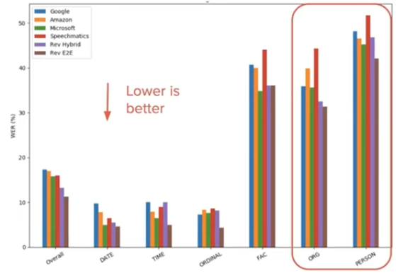

## Bias

Debido a los diferentes acentos que hay, es que el desempeño del sistema va a cambiar, provocando mayores errores para personas con un cierto acento que otras personas con acentos comunes dentro del conjunto de datos.

Estos sistemas dependen de diferentes variables, el objetivo es lograr elabroar un sistema lo más amplio posible, de manera que pueda realizar transcripciones independientemente del tipo de contenido del audio, características de quien está hablando, ruido y condiciones del canal.

## Selección de datos y segmentación

- Verbatim: Se requieren transcriptores que realicen correcciones a las transcripciones realizadas por el sistema para obtener un resultado lo más coherente posible.
- Los audios se dividen en diferentes oraciones para el entrenamiento, pero al momento de probar el modelo, no se puede dividir el audio en segmentos en tiempo real.

## Características de la señal

Lo mejor para poder obtener características de la señal es primero realizar un procesamiento de la misma. Se toma para cada tiempo un vector con la energía de la señal en diferentes frecuencias. Para esta parte se utiliza la escala de Mel para tratar de imitar la forma en la que los humanos procesan el audio.

## Generación de texto

Hay diferentes maneras de generar texto:

- Palabra por palabra
- Letra por letra
- Utilizando subunidades.

## Encoder - Decoder con atención

Es un modelo que puede aplicarse a una variedad de problemas de secuencias de datos.

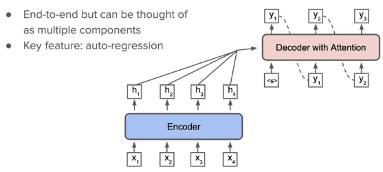

### Capas

- **Embedding:** Se trata a la señal de audio como una imagen y se utiliza una red convolucional
- Se utilizan diferentes modelos de redes neuronales para continuar con el procesamiento y clasificación de la señal.
  - RNNS: se utilizaban comúnmente LSTM pero han sido sustituídas por Transformers.
  - Transformers: Mejoran el entrenamiento haciéndolo más eficiente.
  - Conformers: Son transformers con una capa convolucional extra después de la capa de atención.

Los modelos basados en atención no suelen ser muy eficientes en el ámbito comercial.

## CTCs

En lugar de redes basadas en atención se utiliza Connectionist Temporal Classification. Lo que requiere este algoritmo para funcionar es que la entrada y salida sean monotónicas, que la salida sea igual o de menor longitud que la entrada. Un modelo basado en CTC no tiene realimentación, se tiene un número fijo de salidas.

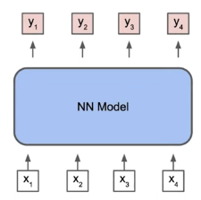

Los modelos que utilizan CTC no son tan buenos como los modelos con encoder-decoder pero sí son mejores que los modelos híbridos (transformers y conformers), además de que son mejores en el tiempo de decodificación.

Para mejorar el desempeño de un modelo CTC se puede añadir un modelo de lenguaje, que pueden ser modelos estadísticos o utilizando redes neuronales. Cuando se utilizan estos dos modelos para poder optimizar todos los parámetros, entonces se le llama **RNN-T**, **Transducer** o **Transducer Transformer**.

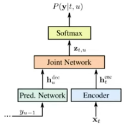

### Modelo CTC/Atención

Se puede tomar el modelo de encoder-decoder y agregar una capa de CTC para tener un buen desempeño y se mejora la velocidad del sistema, haciéndolo viable para fines comerciales.

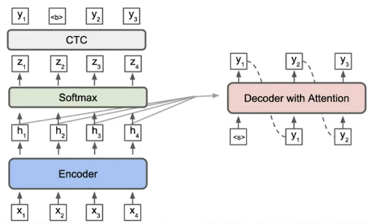

Primero entran los datos al encoder y se obtienen salidas mediante CTC, obteniendo una lista de hipótesis; luego se utiliza el decoder, donde entran las hipótesis del CTC y se obtiene la mejor.